# PEC4_EDUARDO_MORA_GONZALEZ

[figure not shown]

M2.855 · Modelos avanzados de minería de datos

2022-2 · Máster universitario en Ciencia de datos (Data science)

Estudios de Informática, Multimedia y Telecomunicación

**Nombre y apellidos: EDUARDO MORA GONZÁLEZ**

# PEC 4: Series temporales y combinación de modelos de regresión

Está actividad está dividida en dos partes:

- **Series temporales**: Descomponer y componer series temporales para realizar predicciones a futuro.
- **Combinación de clasificadores**: Estudio de diferentes métodos de combinación de clasificadores.

Consideraciones generales:

- La solución planteada no puede utilizar métodos, funciones o parámetros declarados *deprecated* en futuras versiones, a excepción de que se indique explícitamente.
- Esta PEC debe realizarse de forma **estrictamente individual**. Cualquier indicio de copia será penalizado con un suspenso (D) para todas las partes implicadas y la posible evaluación negativa de la asignatura de forma íntegra.
- Es necesario que el estudiante indique **todas las fuentes** que ha utilizado para la realización de la PEC. De no ser así, se considerará que el estudiante ha cometido plagio, siendo penalizado con un suspenso (D) y la posible evaluación negativa de la asignatura de forma íntegra.
- En esta PEC se deben usar **únicamente las librerías que se importan a continuación**. Si se desea usar otra librería hay que consultarlo con el tutor/tutora del aula.

Formato de la entrega:

- Algunos ejercicios pueden suponer varios minutos de ejecución, por lo que la entrega debe hacerse en **formato notebook** y en **formato html**, donde se vea el código, los resultados y comentarios de cada ejercicio. Se puede exportar el notebook a HTML desde el menú File $\to$ Download as $\to$ HTML.
- Existe un tipo de celda especial para albergar texto. Este tipo de celda os será muy útil para responder a las diferentes preguntas teóricas planteadas a lo largo de la actividad. Para cambiar el tipo de celda a este tipo, en el menú: Cell $\to$ Cell Type $\to$ Markdown.

Iniciamos la PEC con la carga de las siguientes librerías:

```python
from matplotlib import pyplot as plt
import pandas as pd
import numpy as np
import scipy.stats
from scipy import stats
from sklearn.linear_model import LinearRegression
from sklearn.neighbors import KNeighborsClassifier
from sklearn.ensemble import RandomForestClassifier
from sklearn.model_selection import cross_val_score
from sklearn.tree import DecisionTreeClassifier
from sklearn.model_selection import train_test_split
from sklearn.model_selection import cross_val_score
from sklearn.metrics import accuracy_score
from sklearn import ensemble
from sklearn import svm

%matplotlib inline
```

# 1. Series temporales (6 puntos)

En este primer ejercicio trabajaremos con series temporales. Para ello, usaremos el dataset **temperatura.csv** que contiene la temperatura media mensual de Barcelona de los últimos 15 años, de 2008 a 2022.

Empezaremos leyendo los datos y observando gráficamente su distribución. Como se puede apreciar, es un claro caso de serie temporal, con heterocedasticidad, tendencia, periodo y ruido. A lo largo de este ejercicio trataremos cada uno de estos puntos.

```python
data = pd.read_csv("/kaggle/input/pec4-datos/temperatura.csv", parse_dates=['Year_Month'], index_col='Year_Month', header=0)
data.head()
```

| Year_Month | Temperature |
| --- | --- |
| 2008-01-01 | 10.1 |
| 2008-02-01 | 10.2 |
| 2008-03-01 | 10.8 |
| 2008-04-01 | 13.7 |
| 2008-05-01 | 16.6 |

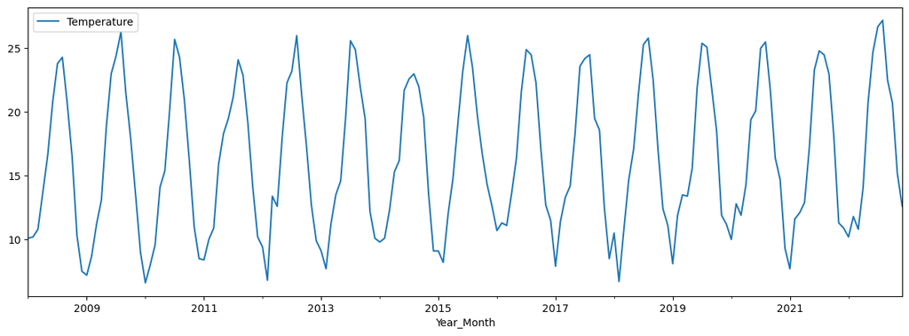

```python
data.plot(figsize=(15, 5))
```

A continuación, vamos a separar los últimos tres años de datos del dataset original, los cuales nos servirán como conjunto de test. Así, cuando hagamos una predicción a futuro podremos comprobar si se ajusta a los datos reales. El resto del conjunto de datos, será nuestro conjunto de datos de entrenamiento.

```python
TEST_SIZE = 36
train, test = data.iloc[:-TEST_SIZE].to_numpy(), data.iloc[-TEST_SIZE:].to_numpy()
x_train, x_test = np.arange(train.shape[0]), np.arange(train.shape[0], data.shape[0])
train.shape, x_train.shape, test.shape, x_test.shape
```

```
((144, 1), (144,), (36, 1), (36,))
```

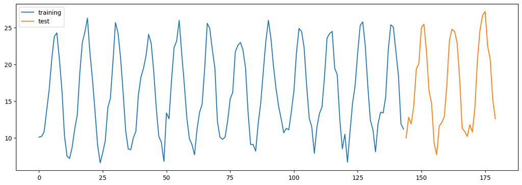

```python
fig, ax = plt.subplots(1, 1, figsize=(15, 5))
ax.plot(x_train, train, label='training')
ax.plot(x_test, test, label='test')
ax.legend()
```

## 1.1 Componentes de la serie temporal

### 1.1.a. Heterocedasticidad

Una serie temporal tiene heterocedasticidad cuando la variancia varía con el tiempo (https://es.wikipedia.org/wiki/Heterocedasticidad). En nuestro caso, observamos que tenemos una leve heterocedasticidad, ya que la amplitud de onda varía levemente con el tiempo. En este primer apartado debéis eliminar la heterocedasticidad de la serie temporal. Es decir, que la diferencia entre el mínimo y el máximo de la estacionalidad (anual) sea más o menos la misma a lo largo del tiempo.

**Implementación:** transforma los **datos de entrenamiento** para eliminar la heterocedasticidad. Para ello debéis transformar los datos aplicando la función que consideréis que elimina mejor la heterocedasticidad en el dataset (exponencial, logarítmica, ...). Estas funciones ya están implementadas en numpy. Graficar los datos originales junto con los datos transformados.

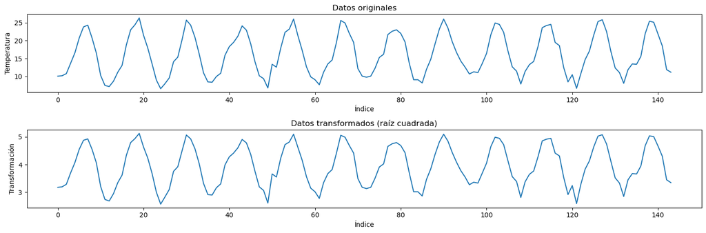

```python
# Aplicar la transformación de la raíz cuadrada a los datos de entrenamiento
train_transformed_sqrt = np.sqrt(train)

# Graficar los datos originales y los transformados
fig, axes = plt.subplots(2, 1, figsize=(15, 5))

axes[0].plot(x_train, train)
axes[0].set_title('Datos originales')
axes[0].set_xlabel('Índice')
axes[0].set_ylabel('Temperatura')

axes[1].plot(x_train, train_transformed_sqrt)
axes[1].set_title('Datos transformados (raíz cuadrada)')
axes[1].set_xlabel('Índice')
axes[1].set_ylabel('Transformación')

plt.tight_layout()
plt.show()
```

### 1.1.b. Tendencia

La tendencia es el comportamento que tienen los datos a largo plazo (https://miro.medium.com/max/1872/1*rDQL2fAp_X_dgAHNZuwRfw.png). En nuestra serie temporal tenemos una ligera tendencia lineal creciente. En este apartado debéis eliminar la tendencia, quedando una serie temporal con tendencia constante.

**Implementación:** elimina la tendencia de los datos transformados en la sección anterior. Observando la serie, podemos apreciar que tenemos una tendencia lineal, por ese motivo, podemos ajustar una regresión lineal (usando scikit-learn) y sustraerla a los datos anteriores (entrenamiento sin heterocedasticidad). En este ejercicio, primero debemos graficar la serie con tendencia junto con la regresión lineal y, a continuación, se debe sustraer la tendencia y graficar la serie resultante (sin tendencia).

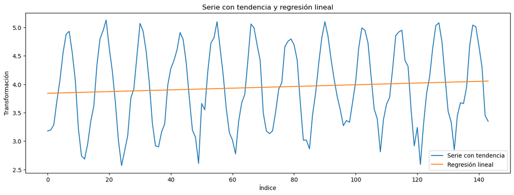

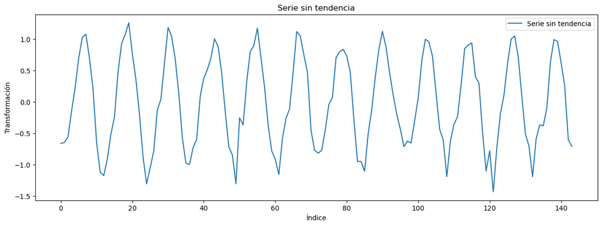

```python
# Ajustar una regresión lineal a los datos transformados
regression_model = LinearRegression()
regression_model.fit(x_train.reshape(-1, 1), train_transformed_sqrt)

# Obtener las predicciones de la regresión lineal
trend = regression_model.predict(x_train.reshape(-1, 1))

# Sustraer la tendencia lineal de los datos transformados
detrended_data = (train_transformed_sqrt - trend).squeeze()

# Graficar la serie con tendencia y la regresión lineal
plt.figure(figsize=(15, 5))
plt.plot(x_train, train_transformed_sqrt, label='Serie con tendencia')
plt.plot(x_train, trend, label='Regresión lineal')
plt.xlabel('Índice')
plt.ylabel('Transformación')
plt.title('Serie con tendencia y regresión lineal')
plt.legend()
plt.show()

# Graficar la serie sin tendencia (datos detrended)
plt.figure(figsize=(15, 5))
plt.plot(x_train, detrended_data, label='Serie sin tendencia')
plt.xlabel('Índice')
plt.ylabel('Transformación')
plt.title('Serie sin tendencia')
plt.legend()
plt.show()
```

### 1.1.c. Estacionalidad

Definimos la estacionalidad como la variación cíclica que se produce en los datos (https://es.wikipedia.org/wiki/Estacionalidad). En este apartado se debe encontrar y eliminar la estacionalidad.

#### 1.1.c.a. Encontrar el periodo de la estacionalidad

**Implementación:** en primer lugar debéis encontrar el ciclo, es decir, cada cuánto se repiten los datos. Para ello, podemos usar la autocorrelación (numpy te permite obtener los coeficientes de correlación). En este ejercicio, se pide graficar los coeficientes para los 22 primeros valores de autocorrelación y determinar su valor máximo, el cual será nuestra estacionalidad. Dar una interpretación semántica del resultado obtenido.

**Nota:** utilizad la serie obtenida en el apartado anterior (sin tendencia ni heterocedasticidad).

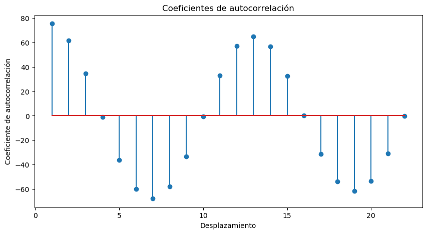

```
Valor máximo de autocorrelación: 75.53675660931388
Desplazamiento correspondiente: 1
```

```python
# Calcular los coeficientes de autocorrelación
autocorr = np.correlate(detrended_data.squeeze(), detrended_data.squeeze(), mode='full')

# Obtener los coeficientes de autocorrelación para los primeros 22 desplazamientos
autocorr = autocorr[len(detrended_data)-1:len(detrended_data)+21]

# Crear un arreglo para los valores de desplazamiento
lags = np.arange(1, 23)

# Graficar los coeficientes de autocorrelación
plt.figure(figsize=(10, 5))
plt.stem(lags, autocorr)
plt.xlabel('Desplazamiento')
plt.ylabel('Coeficiente de autocorrelación')
plt.title('Coeficientes de autocorrelación')
plt.show()

# Encontrar el valor máximo y su correspondiente desplazamiento
max_corr = np.max(autocorr)
max_lag = lags[np.argmax(autocorr)]

print("Valor máximo de autocorrelación:", max_corr)
print("Desplazamiento correspondiente:", max_lag)
```

#### 1.1.c.b. Calcular el patrón de estacionalidad

**Implementación:** ahora que ya conocéis el ciclo, debéis calcular el patrón (el molde de la estacionalidad). Es decir, para cada punto del ciclo, calcular la mediana de ese punto en cada uno de los ciclos de la serie.

**Nota:** utilizad la serie obtenida en el apartado anterior (sin tendencia ni heterocedasticidad).

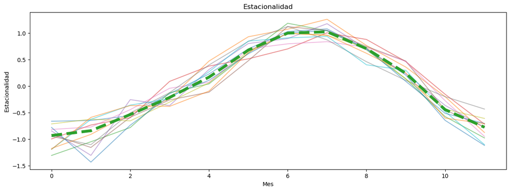

```python
# Crea una matriz vacía de dimensiones para almacenar la estacionalidad
seasonality = np.zeros((int(detrended_data.size/12), 12))

# Crea una figura y un único eje para el gráfico
_, ax = plt.subplots(1, 1, figsize=(15, 5))

# Itera sobre los datos detrended_data en intervalos de 12 meses
for i, j in enumerate(range(0, detrended_data.size, 12)):
    # Almacena los datos de cada año en la matriz estacionalidad
    seasonality[i,:] = detrended_data[j:j + 12]

    # Grafica los datos de cada año con una transparencia de 0.5
    ax.plot(range(12), detrended_data[j:j + 12], alpha=.5)

# Calcula la mediana de la matriz estacionalidad a lo largo del eje 0 (filas)
median_seasonality = np.median(seasonality, axis=0)

# Grafica la línea punteada que representa la mediana de la estacionalidad
ax.plot(range(12), median_seasonality, '--', lw=5)
ax.set_xlabel('Mes')
ax.set_ylabel('Estacionalidad')
ax.set_title('Estacionalidad')
plt.show()
```

**Implementación:** una vez obtenido el patrón, replicadlo a lo largo de toda la serie temporal. Cuando lo hayáis calculado, debéis restarlo de la serie temporal (sin tendencia ni heterocedasticidad). Graficar los datos con estacionalidad junto con los datos sin estacionalidad.

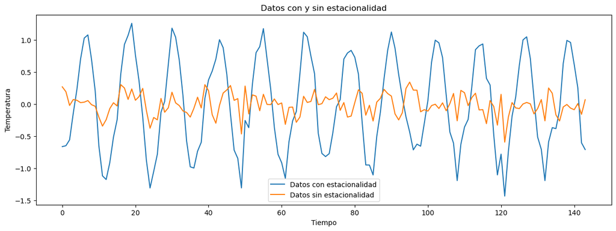

```python
# Calcular el número de ciclos completos en la serie
num_cycles = int(detrended_data.size / 12)

# Replicar el patrón de estacionalidad a lo largo de todos los ciclos completos
replicated_seasonality = np.tile(median_seasonality, num_cycles)

# Calcular la diferencia entre la serie temporal sin estacionalidad y el patrón replicado
series_without_seasonality = detrended_data - replicated_seasonality

# Crear una figura y un único eje para el gráfico
_, ax = plt.subplots(1, 1, figsize=(15, 5))

# Graficar los datos con estacionalidad y sin estacionalidad
ax.plot(x_train, detrended_data, label='Datos con estacionalidad')
ax.plot(x_train, series_without_seasonality, label='Datos sin estacionalidad')

# Establecer etiquetas de los ejes y título del gráfico
ax.set_xlabel('Tiempo')
ax.set_ylabel('Temperatura')
ax.set_title('Datos con y sin estacionalidad')
ax.legend()
plt.show()
```

### 1.1.d. Ruido

Una vez eliminadas la heterocedasticidad, la tendencia y la estacionalidad, lo que nos queda es el ruido. El ruido sigue una distribución normal. En este apartado debéis encontrar los parámetros de la distribución que sigue el ruido (media y desviación estandard).

**Implementación:** encontrar la distribución que tiene el ruido (media y desviación estándard) usando el ruido obtenido en el apartado anterior, es decir, la serie sin heterocedasticidad, tendencia y estacionalidad. Podéis usar scipy.stats. Por último, graficad un histograma del ruido junto con un histograma de la distribución teórica que tiene el ruido.

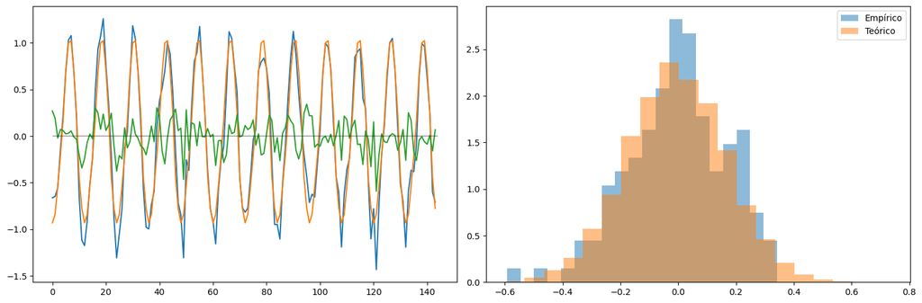

```python
# Ajustar una distribución normal a los datos de ruido
mean, sigma = scipy.stats.norm.fit(series_without_seasonality)

# Crear una figura con dos subfiguras (ax[0] y ax[1])
_, ax = plt.subplots(1, 2, figsize=(15, 5))

# Graficar la serie temporal de la tendencia
ax[0].plot(x_train, detrended_data, label='Tendencia')

# Graficar la serie temporal de la estacionalidad completa
ax[0].plot(x_train, replicated_seasonality, label='Estacionalidad')

# Graficar la serie temporal de ruido
ax[0].plot(x_train, series_without_seasonality, label='Ruido')

# Dibujar una línea horizontal en y=0
ax[0].hlines(0, 0, x_train.size, 'k', alpha=.3)

# Graficar un histograma de los datos de ruido empíricos
ax[1].hist(series_without_seasonality, 20, alpha=.5, label='Empírico', density=1)

# Graficar un histograma de los datos de ruido teóricos generados con una distribución normal
ax[1].hist(np.random.normal(mean, sigma, size=x_train.size * 100), 20, alpha=.5, label='Teórico', density=1)
ax[1].legend()
plt.tight_layout()
plt.show()
```

## 1.2. Predicción

Una vez que hemos descompuesto la serie temporal (de entrenamiento), vamos a predecir los tres proximos años y comparar la predicción con los datos reales. Para ello seguiremos los siguientes pasos:

- Generar ruido
- Añadir estacionalidad
- Añadir tendencia
- Añadir heterocedasticidad

### 1.2.a. Ruido

Como hemos visto que el ruido se distribuye aleatoriamente siguiendo una distribución normal, vamos a generar ruido siguiendo esta distribución.

**Implementación:** genera tres años de datos de ruido (36 muestras) usando la distribución encontrada en el apartado 1.1.d. Podéis usar el módulo random de numpy. Por último, graficad el resultado.

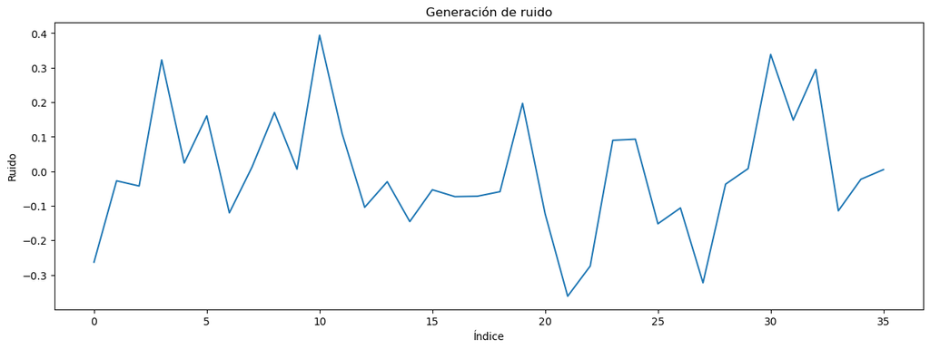

```python
# Generar tres años de datos de ruido
num_samples = 12*3  # 12 meses * 3 años
random_noise = np.random.normal(mean, sigma, num_samples)

# Graficar el resultado
plt.figure(figsize=(15, 5))
plt.plot(range(TEST_SIZE), random_noise)
plt.xlabel('Índice')
plt.ylabel('Ruido')
plt.title('Generación de ruido')
plt.show()
```

### 1.2.b. Estacionalidad

Anteriormente hemos calculado la estacionalidad y el ciclo de la serie temporal. Vamos a usar esa estacionalidad ya calculada para añadirla a nuestra predicción.

**Implementación:** añade a los tres años de ruido calculados en el apartado anterior, la estacionalidad encontrada en el apartado 1.1.c. Grafica el resultado.

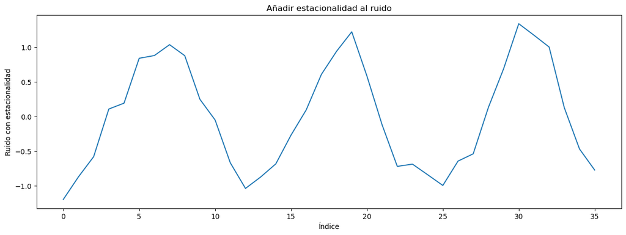

```python
# Añadir la estacionalidad a los datos de ruido
noise_with_seasonality = random_noise + np.tile(median_seasonality, int(TEST_SIZE / 12))

# Graficar el resultado
plt.figure(figsize=(15, 5))
plt.plot(range(TEST_SIZE), noise_with_seasonality)
plt.xlabel('Índice')
plt.ylabel('Ruido con estacionalidad')
plt.title('Añadir estacionalidad al ruido')
plt.show()
```

### 1.2.c. Tendencia

En la sección 1.1.b hemos visto que los datos de la serie temporal tienen una tendencia lineal y la hemos calculado mediante una regresión lineal. Ahora, vamos a añadir esta tendencia a nuestra predicción.

**Implementación:** añade a los tres años de ruido y estacionalidad calculados en el apartado anterior, la tendencia encontrada en el apartado 1.1.b. Por último, graficad la serie obtenida.

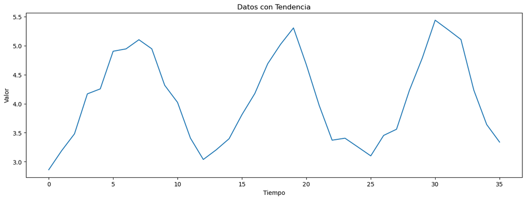

```python
# Añadir la tendencia a los datos de ruido y estacionalidad
data_with_trend = noise_with_seasonality + regression_model.predict(x_test.reshape(-1, 1)).squeeze()

# Crear una figura con un único eje
_, ax = plt.subplots(1, 1, figsize=(15, 5))

# Graficar los datos con la tendencia
ax.plot(range(TEST_SIZE), data_with_trend)
ax.set_title('Datos con Tendencia')
ax.set_xlabel('Tiempo')
ax.set_ylabel('Valor')
plt.show()
```

### 1.2.d. Heterocedasticidad

En el primer apartado de esta práctica hemos visto que la serie temporal tiene heterocedasticidad y la hemos eliminado transformando los datos. En este apartado haremos la transfromación inversa para añadir heterocedasticidad a nuestra predicción.

**Implementación:** añade a los tres años de ruido, estacionalidad y tendencia calculados en el apartado anterior, la heterocedasticidad, aplicando la función inversa a la encontrada en el apartado 1.1.a. Grafica el resultado junto con la serie completa y compara la predicción obtenida con los datos reales.

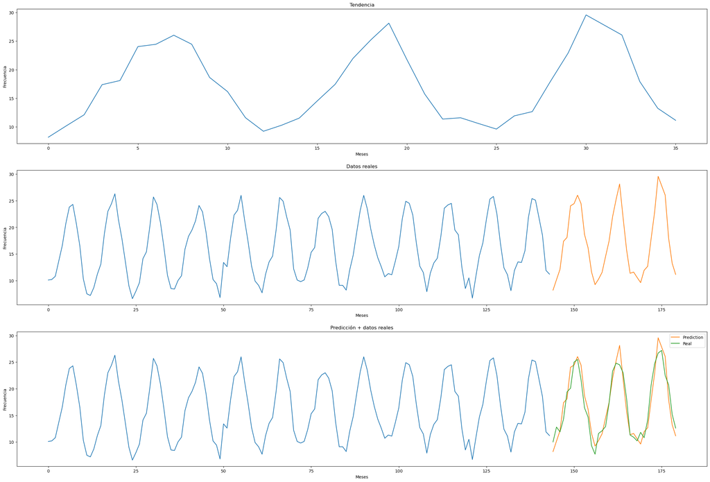

```python
prediction = np.square(data_with_trend)

_, ax = plt.subplots(3, 1, figsize=(30, 20))
ax[0].plot(range(TEST_SIZE), prediction)
ax[0].title.set_text('Tendencia')
ax[0].set(xlabel="Meses",ylabel="Frecuencia")

ax[1].plot(x_train, train)
ax[1].plot(x_test, prediction)
ax[1].title.set_text('Datos reales')
ax[1].set(xlabel="Meses",ylabel="Frecuencia")

ax[2].plot(x_train, train)
ax[2].plot(x_test, prediction, label='Prediction')
ax[2].plot(x_test, test, label='Real')
ax[2].title.set_text('Predicción + datos reales')
ax[2].set(xlabel="Meses",ylabel="Frecuencia")
ax[2].legend()
```

**Análisis:** Analizad los resultados obtenidos.

Durante este ejercicio, hemos realizado diferentes cálculos para analizar y modelar los datos de prueba, incluyendo la evaluación de la heterocedasticidad, la identificación de la tendencia, la determinación de la estacionalidad y el análisis del ruido. Estos cálculos nos han permitido realizar predicciones de los datos.

Al observar los resultados de nuestras predicciones, podemos concluir que han sido bastante precisas en general. Aunque en los últimos dos años se observa una ligera discrepancia entre los datos predichos y los datos reales, en su mayoría, los datos predichos se asemejan a los datos reales.

# 2. Combinación de clasificadores (4 puntos)

El ensemble learning es una estrategia en la que se utiliza un grupo de modelos para resolver un problema mediante la combinación estratégica de diversos modelos de aprendizaje automático en un sólo modelo predictivo.

En general, los métodos de ensemble se utilizan principalmente para mejorar la precisión del rendimiento general de un modelo y combinar varios modelos diferentes, también conocidos como aprendices básicos, para predecir los resultados, en lugar de utilizar un sólo modelo.

¿Por qué entrenamos tantos clasificadores diferentes en lugar de uno solo? Bueno, el uso de varios modelos para predecir el resultado final en realidad reduce la probabilidad de sopesar las decisiones tomadas por modelos deficientes (sobreentrenados, no debidamente ajustados...).

Cuanto más diversos sean estos aprendices básicos, más poderoso será el modelo final.

Tengamos en cuenta que en cualquier modelo de aprendizaje automático, el error de generalización viene dado por la suma de cuadrados de bias + varianza + error irreductible.

¡Los errores irreductibles son algo que está más allá de nosotros! No podemos reducirlos.

Sin embargo, utilizando ensembles, podemos reducir el sesgo (bias) y la varianza de un modelo. Esto reduce el error de generalización general.

La **compensación de sesgo-varianza** es el punto de referencia más importante que diferencia un modelo robusto de uno inferior (entendamos por inferior un modelo no demasiado generalizable).

Aunque no es una regla exacta, en el aprendizaje automático, los modelos que tienen un sesgo alto tienden a tener una varianza más baja y viceversa.

Hemos estado hablando de bias y varianza. Pero veamos que entendemos por sesgo de un modelo y por varianza de un modelo.

1. **Sesgo**: El sesgo es un error que surge debido a suposiciones falsas realizadas en la fase de aprendizaje de un modelo. Un sesgo alto puede hacer que un algoritmo de aprendizaje omita información importante y correlaciones entre las variables independientes y las etiquetas de clase, por lo que no se ajusta al modelo.
2. **Varianza**: la varianza nos dice qué tan sensible es un modelo a los pequeños cambios en los datos de entrenamiento. Es decir, cuánto cambia el modelo. Una gran variación en un modelo lo hará propenso al ruido aleatorio presente en el conjunto de datos, por lo que se ajustará demasiado al modelo.

Para comprender con más detalle la compensación de sesgo y varianza en los modelos de aprendizaje automático, podeís consultar este [artículo](https://towardsdatascience.com/understanding-the-bias-variance-tradeoff-165e6942b229).

Una vez llegados a este punto, podemos dividir los ensembles en cuatro categorías:

1. **Bagging**: El bagging se utiliza principalmente para reducir la variación en un modelo. Un ejemplo simple de bagging es el algoritmo Random Forest.
2. **Boosting**: El boosting se utiliza principalmente para reducir el sesgo en un modelo. Ejemplos de algoritmos de impulso son Ada-Boost, XGBoost, árboles de decisión mejorados por gradiente, etc.
3. **Stacking**: el stacking se utiliza principalmente para aumentar la precisión de predicción de un modelo.
4. **Cascading**: esta clase de modelos son muy precisos. La conexión en cascada se usa principalmente en escenarios en los que no puede permitirse cometer un error. Por ejemplo, una técnica en cascada se usa principalmente para detectar transacciones fraudulentas con tarjetas de crédito.

## Datos

Para este ejercicio usaremos el dataset **diabetes.csv**. Este conjunto de datos es original del Instituto Nacional de Diabetes y Enfermedades Digestivas y Renales. El objetivo de este dataset es predecir, basándose en las mediciones de diagnóstico, si un paciente tiene diabetes.

En particular, todos los pacientes aquí son mujeres de al menos 21 años de ascendencia india Pima.

El dataset contiene la siguiente información:

- Embarazos: número de embarazos
- Glucosa: concentración de glucosa en plasma a 2 horas en una prueba de tolerancia a la glucosa oral
- Presión arterial: presión arterial diastólica (mm Hg)
- SkinThickness: Espesor del pliegue cutáneo del tríceps (mm)
- Insulina: insulina sérica de 2 horas (mu U / ml)
- IMC: índice de masa corporal (peso en kg / (altura en m) ^ 2)
- DiabetesPedigreeFunction: función del pedigrí de la diabetes
- Edad: Edad (años)
- Resultado (variable objetivo): variable de clase (0 o 1)

En la primera parte de este ejercicio veremos la combinación de clasificadores en paralelo mediante las tecnicas de **Bagging** y **Boosting**.

En la segunda parte intentaremos mejorar los resultados aplicando tecnicas de combinación secuencial de clasificadores: **Stacking** y **Cascading**.

Para empezar, veamos como es el dataset.

```python
diabetes = pd.read_csv('/kaggle/input/pec4-datos/diabetes.csv')

nRow, nCol = diabetes.shape
print(f'Hay {nRow} filas y {nCol} columnas')
diabetes.head()
```

```
Hay 768 filas y 9 columnas
```

|  | Pregnancies | Glucose | BloodPressure | SkinThickness | Insulin | BMI | DiabetesPedigreeFunction | Age | Outcome |
| --- | --- | --- | --- | --- | --- | --- | --- | --- | --- |
| 0 | 6 | 148 | 72 | 35 | 0 | 33.6 | 0.627 | 50 | 1 |
| 1 | 1 | 85 | 66 | 29 | 0 | 26.6 | 0.351 | 31 | 0 |
| 2 | 8 | 183 | 64 | 0 | 0 | 23.3 | 0.672 | 32 | 1 |
| 3 | 1 | 89 | 66 | 23 | 94 | 28.1 | 0.167 | 21 | 0 |
| 4 | 0 | 137 | 40 | 35 | 168 | 43.1 | 2.288 | 33 | 1 |

Para poder probar varios modelos, primero vamos a dividir el dataset entre train y test. Además, para que todos obtengáis los mismos resultados y poder comentar dudas por el foro/correo, fijaremos la seed para obtener los mismos datasets de train y test.

Como en este ejercicio trataremos stacking y cascading, y ambos se aplican sobre el conjunto de test, haremos un split del 60% para tener un poco más de base al aplicar estas dos técnicas.

```python
myseed = 13
X = diabetes.drop(columns = 'Outcome')
y = diabetes['Outcome']

X_train, X_test, y_train, y_test = train_test_split(X, y, test_size=0.6, random_state=myseed)
```

## 2.1. Combinación paralela de clasificadores (1.5 puntos)

### 2.1.1. Árboles de decisión

Para poder comparar el aumento de performance obtenido a medida que vamos aplicando técnicas nuevas, utilizaremos como baseline un simple árbol de decisión.

**Implementación:** Define un árbol de decisión con profundidad máxima de 3 niveles (aplicaremos la misma restricción en las siguientes secciones), utilizando la semilla definida en el apartado anterior y calcula su precisión sobre el conjunto de train aplicando validación cruzada con 5 conjuntos. A continuación, entrena el árbol de decisión sobre el conjunto de datos de train y evalua sobre test utilizando la precisión como métrica ('accuracy'). **Sugerencia:** usar el módulo **cross_val_score** de **sklearn**.

Para aprender más sobre **cross validation** y sobre como usar estos módulos, os recomendamos los siguientes enlaces:

- [cross_val_score](http://scikit-learn.org/stable/modules/generated/sklearn.model_selection.cross_val_score.html)
- [cross_validation](http://scikit-learn.org/stable/modules/cross_validation.html)

```python
# Define the decision tree classifier with max depth of 3
decision_tree = DecisionTreeClassifier(max_depth=3, random_state=myseed)

# Perform cross-validation on the training set
cv_scores = cross_val_score(decision_tree, X_train, y_train, cv=5)

# Calculate the mean accuracy across all cross-validation folds
mean_accuracy = cv_scores.mean()

# Train the decision tree on the entire training set
decision_tree.fit(X_train, y_train)

# Evaluate the decision tree on the test set
accuracy = decision_tree.score(X_test, y_test)

print("Mean Accuracy (Cross-Validation):", mean_accuracy)
print("Accuracy on Test Set:", accuracy)
```

```
Mean Accuracy (Cross-Validation): 0.7006874669487043
Accuracy on Test Set: 0.7288503253796096
```

**Análisis:** Analizad los resultados obtenidos.

Basándonos en los resultados obtenidos, la precisión promedio de la validación cruzada de 5 pliegues es aproximadamente 0.7007, mientras que la precisión en el conjunto de prueba es aproximadamente 0.7289.

La precisión promedio de la validación cruzada nos da una estimación de qué tan bien se desempeña el árbol de decisión en promedio en diferentes pliegues de los datos de entrenamiento. En este caso, sugiere que el árbol de decisión logra una precisión promedio de alrededor del 70.07% en datos no vistos.

La precisión en el conjunto de prueba proporciona una indicación de qué tan bien generaliza el árbol de decisión a datos nuevos y no vistos. La precisión de aproximadamente el 72.89% sugiere que el árbol de decisión tiene un desempeño razonable en el conjunto de prueba, pero aún hay margen de mejora.

### 2.1.2. Bagging

La idea central del bagging es usar réplicas del conjunto de datos original y usarlas para entrenar diferentes clasificadores.

Crearemos subconjuntos muestreando aleatoriamente un montón de puntos del conjunto de datos de entrenamiento con reemplazo.

Ahora entrenaremos clasificadores individuales en cada uno de estos subconjuntos bootstrap.

Cada uno de estos clasificadores base predecirá la etiqueta de clase para un problema dado. Aquí es donde combinamos las predicciones de todos los modelos base. Esta parte se llama etapa de agregación. Es por eso que encontraréis los ensembles bagging por el nombre de ensembles de agregación.

Por lo general, se usa un voto de mayoría simple en un sistema de clasificación y se toma la media de todas las predicciones para los modelos de regresión para combinar todos los clasificadores base en un solo modelo y proporcionar el resultado final del modelo de conjunto.

Un ejemplo simple de tal enfoque es el algoritmo Random Forest. El bagging reduce la alta variación (varianza) de un modelo, reduciendo así el error de generalización. Es un método muy eficaz, especialmente cuando tenemos datos muy limitados con pudiera ser nuestro caso.

Mediante el uso de muestras de bootstrap, podemos obtener una estimación agregando las puntuaciones de muchas muestras.

**¿Cómo haríamos bagging?**

Supongamos que tenemos un conjunto de entrenamiento que contiene 100.000 puntos de datos.

Crearíamos N subconjuntos muestreando al azar 50K puntos de datos para cada subconjunto.

Cada uno de estos N subconjuntos se utilizará para entrenar N clasificadores diferentes.

En la etapa de agregación, todas estas N predicciones se combinarán en un solo modelo, también llamado metaclasificador.

De los 100.000 puntos presentes originalmente en el conjunto de datos, si eliminamos 1000 puntos, el impacto que tendrá en los conjuntos de datos muestreados será muy inferior.

Si pensamos intuitivamente, es posible que algunos de estos 1000 puntos no estén presentes en todos los conjuntos de datos muestreados y, por lo tanto, la cantidad de puntos que se eliminarán de cada conjunto de datos muestreados será muy inferior. ¡Incluso cero en algunos casos! En resumen, el impacto de eliminar 1000 puntos de este tipo será en realidad menor en los clasificadores base, lo que reducirá la variación en un modelo y lo hará más sólido.

La varianza no es más que sensibilidad al ruido, como hemos comentado anteriormente.

**Implementación:** Define un Random Forest Classifier con 20 árboles de decisión y profundidad máxima de 3 niveles, utilizando la semilla definida al inicio del segundo ejercicio, y calcula su precisión sobre el conjunto de train aplicando validación cruzada con 5 conjuntos. A continuación, entrena el modelo sobre el conjunto de datos de train y evalua sobre test utilizando la precisión como métrica ('accuracy').

**Sugerencia:** Usar el módulo `RandomForestClassifier` de **sklearn**.

Para apender a usar este módulo os recomendamos el siguiente:

- [RandomForestClassifier](http://scikit-learn.org/stable/modules/generated/sklearn.ensemble.RandomForestClassifier.html)

```python
# Define the random forest classifier with 20 decision trees and max depth of 3
random_forest = RandomForestClassifier(n_estimators=20, max_depth=3, random_state=myseed)

# Perform cross-validation on the training set
cv_scores = cross_val_score(random_forest, X_train, y_train, cv=5)

# Calculate the mean accuracy across all cross-validation folds
mean_accuracy = cv_scores.mean()

# Train the random forest on the entire training set
random_forest.fit(X_train, y_train)

# Evaluate the random forest on the test set
accuracy = random_forest.score(X_test, y_test)

print("Mean Accuracy (Cross-Validation):", mean_accuracy)
print("Accuracy on Test Set:", accuracy)
```

```
Mean Accuracy (Cross-Validation): 0.7361713379164463
Accuracy on Test Set: 0.7527114967462039
```

**Análisis:** Analizad los resultados obtenidos.

Basándonos en los resultados obtenidos, la precisión promedio de la validación cruzada de 5 pliegues es aproximadamente 0.7362, mientras que la precisión en el conjunto de prueba es aproximadamente 0.7527.

La precisión promedio de la validación cruzada nos da una estimación de qué tan bien se desempeña el modelo de Random Forest en promedio en diferentes pliegues de los datos de entrenamiento. En este caso, sugiere que el modelo logra una precisión promedio de alrededor del 73.62% en datos no vistos.

La precisión en el conjunto de prueba proporciona una indicación de qué tan bien generaliza el modelo de Random Forest a datos nuevos y no vistos. La precisión de aproximadamente el 75.27% sugiere que el modelo tiene un desempeño razonable en el conjunto de prueba, pero aún hay margen de mejora.

Al comparar estos resultados con los obtenidos anteriormente con el árbol de decisión de profundidad 3, podemos observar una mejora en la precisión tanto en la validación cruzada como en el conjunto de prueba. Esto se debe a que Random Forest utiliza múltiples árboles de decisión y combina sus resultados, lo que puede ayudar a reducir la varianza y mejorar el rendimiento general del modelo.

### 2.1.3. Boosting

El boosting se utiliza para convertir a los clasificadores de base débil en fuertes. Los clasificadores débiles generalmente tienen una correlación muy débil con las etiquetas de clase verdaderas y los clasificadores fuertes tienen una correlación muy alta entre el modelo y las etiquetas de clase verdaderas.

El boosting capacita a los clasificadores débiles de manera iterativa, cada uno tratando de corregir el error cometido por el modelo anterior. Esto se logra entrenando un modelo débil en todos los datos de entrenamiento, luego construyendo un segundo modelo que tiene como objetivo corregir los errores cometidos por el primer modelo. Luego construimos un tercer modelo que intenta corregir los errores cometidos por el segundo modelo y así sucesivamente. Los modelos se agregan de forma iterativa hasta que el modelo final ha corregido todos los errores cometidos por todos los modelos anteriores.

Cuando se agregan los modelos en cada etapa, se asignan algunos pesos al modelo que está relacionado con la precisión del modelo anterior. Después de agregar un clasificador débil, los pesos se vuelven a ajustar. Los puntos clasificados incorrectamente reciben pesos más altos y los puntos clasificados correctamente reciben pesos más bajos. Este enfoque hará que el siguiente clasificador se centre en los errores cometidos por el modelo anterior.

El boosting reduce el error de generalización tomando un modelo de alto bias y baja varianza y reduciendo el bias en un nivel significativo. Recuerde, el bagging reduce la varianza. Al igual que el bagging, el boosting también nos permite trabajar con modelos de clasificación y regresión.

**Implementación:** Define un Gradient Boosting Classifier con 20 árboles de decisión y profundidad máxima de 3 niveles, utilizando la semilla definida al inicio del segundo ejercicio, y calcula su precisión sobre el conjunto de train aplicando validación cruzada con 5 conjuntos. A continuación, entrena el modelo sobre el conjunto de datos de train y evalua sobre test utilizando la precisión como métrica ('accuracy').

**Sugerencia:**

- Usar el módulo [GradientBoostingClassifier](http://scikit-learn.org/stable/modules/generated/sklearn.ensemble.GradientBoostingClassifier.html) de **sklearn**.

```python
from sklearn.ensemble import GradientBoostingClassifier
from sklearn.model_selection import cross_val_score

# Define the gradient boosting classifier with 20 decision trees and max depth of 3
gradient_boosting = GradientBoostingClassifier(n_estimators=20, max_depth=3, random_state=myseed)

# Perform cross-validation on the training set
cv_scores = cross_val_score(gradient_boosting, X_train, y_train, cv=5)

# Calculate the mean accuracy across all cross-validation folds
mean_accuracy = cv_scores.mean()

# Train the gradient boosting on the entire training set
gradient_boosting.fit(X_train, y_train)

# Evaluate the gradient boosting on the test set
accuracy = gradient_boosting.score(X_test, y_test)

print("Mean Accuracy (Cross-Validation):", mean_accuracy)
print("Accuracy on Test Set:", accuracy)
```

```
Mean Accuracy (Cross-Validation): 0.7461660497091487
Accuracy on Test Set: 0.7527114967462039
```

**Análisis:** Analizad los resultados obtenidos.

Basándonos en los resultados obtenidos, la precisión promedio de la validación cruzada de 5 pliegues es aproximadamente 0.7462, mientras que la precisión en el conjunto de prueba es aproximadamente 0.7527.

La precisión promedio de la validación cruzada nos da una estimación de qué tan bien se desempeña el modelo de Gradient Boosting en promedio en diferentes pliegues de los datos de entrenamiento. En este caso, sugiere que el modelo logra una precisión promedio de alrededor del 74.62% en datos no vistos.

La precisión en el conjunto de prueba proporciona una indicación de qué tan bien generaliza el modelo de Gradient Boosting a datos nuevos y no vistos. La precisión de aproximadamente el 75.27% sugiere que el modelo tiene un desempeño razonable en el conjunto de prueba, pero aún hay margen de mejora.

## 2.2. Combinación secuencial de clasificadores base diferentes (2.5 puntos)

Para poder hacer combinación secuencial de modelos, necesitamos tener varios modelos diferentes entrenados. En nuestro caso, ya tenemos un árbol de decisión. Vamos a entrenar un par de modelos más.

### 2.2.1 KNN (k vecinos más próximos)

**Implementación:** Define un K-Neighbors Classifier con 2 vecinos y calcula su precisión sobre el conjunto de train aplicando validación cruzada con 5 conjuntos. A continuación, entrena el modelo sobre el conjunto de datos de train y evalua sobre test utilizando la precisión como métrica ('accuracy').

```python
from sklearn.neighbors import KNeighborsClassifier
from sklearn.model_selection import cross_val_score

# Define the KNN classifier with 2 neighbors
knn = KNeighborsClassifier(n_neighbors=2)

# Perform cross-validation on the training set
cv_scores = cross_val_score(knn, X_train, y_train, cv=5)

# Calculate the mean accuracy across all cross-validation folds
mean_accuracy = cv_scores.mean()

# Train the KNN on the entire training set
knn.fit(X_train, y_train)

# Evaluate the KNN on the test set
accuracy = knn.score(X_test, y_test)

print("Mean Accuracy (Cross-Validation):", mean_accuracy)
print("Accuracy on Test Set:", accuracy)
```

```
Mean Accuracy (Cross-Validation): 0.7004230565838181
Accuracy on Test Set: 0.6832971800433839
```

### 2.2.2 SVM (Support Vector Machines)

**Implementación:** Define un SVM con gamma = 0.07 y calcula su precisión sobre el conjunto de train aplicando validación cruzada con 5 conjuntos. A continuación, entrena el modelo sobre el conjunto de datos de train y evalua sobre test utilizando la precisión como métrica ('accuracy').

```python
from sklearn.svm import SVC
from sklearn.model_selection import cross_val_score

# Define the SVM classifier with gamma = 0.07
svm = SVC(gamma=0.07)

# Perform cross-validation on the training set
cv_scores = cross_val_score(svm, X_train, y_train, cv=5)

# Calculate the mean accuracy across all cross-validation folds
mean_accuracy = cv_scores.mean()

# Train the SVM on the entire training set
svm.fit(X_train, y_train)

# Evaluate the SVM on the test set
accuracy = svm.score(X_test, y_test)

print("Mean Accuracy (Cross-Validation):", mean_accuracy)
print("Accuracy on Test Set:", accuracy)
```

```
Mean Accuracy (Cross-Validation): 0.6612374405076678
Accuracy on Test Set: 0.6442516268980477
```

### 2.2.3 Stacking

Todos los modelos individuales se entrenan por separado en el conjunto completo de datos de entrenamiento y se ajustan para lograr una mayor precisión. La compensación de bias y varianza se tiene en cuenta para cada modelo. El modelo final, también conocido como metaclasificador, se alimenta de las etiquetas de clase predichas por los modelos base o de las probabilidades predichas para cada etiqueta de clase. Luego, el metaclasificador se entrena en función de los resultados dados por los modelos base.

En el stacking, se entrena un nuevo modelo en función de las predicciones realizadas por los modelos anteriores. Este proceso se lleva a cabo de forma secuencial. Esto significa que varios modelos se entrenan en la etapa 1 y se ajustan con precisión. Las probabilidades pronosticadas de cada modelo de la etapa 1 se alimentan como entrada a todos los modelos en la etapa 2. Los modelos en la etapa 2 luego se ajustan con precisión y las salidas correspondientes se alimentan a los modelos en la etapa 3 y así sucesivamente. Este proceso se produce varias veces en función de la cantidad de capas de apilamiento que desee utilizar.

La etapa final consiste en un único modelo que nos da el resultado final al combinar el resultado de todos los modelos presentes en las capas anteriores.

A menudo, el uso de clasificadores apilables aumenta la precisión de predicción de un modelo. ¡Pero de ninguna manera puede garantizarse que el uso de apilamiento aumente la precisión de la predicción en todo momento! Echad un vistazo al siguiente [link](http://rasbt.github.io/mlxtend/user_guide/classifier/StackingClassifier/).

**Implementación:** Construye un clasificador de tipo stacking usando un Gradient Boosting Classifier (con 20 árboles de decisión, profundidad máxima de 3 niveles y la semilla definida al inicio del segundo ejercicio) que use como atributos las predicciones hechas en el conjunto de test por los algoritmos: árbol de decisión, knn y svm. A continuación, calcula la precisión del modelo resultante con **cross-validation** en el conjunto de test (en este caso no tenemos conjunto de train, con lo cual se hace directamente cross-validation sobre test).

**Sugerencia:**

- Usar la función `column_stack` de **numpy** para juntar todas las predicciones.

Para más información, puedes consultar este enlace:

- [column_stack](https://docs.scipy.org/doc/numpy-1.14.0/reference/generated/numpy.column_stack.html)

```python
import numpy as np
from sklearn.ensemble import GradientBoostingClassifier
from sklearn.model_selection import cross_val_score
from sklearn.tree import DecisionTreeClassifier
from sklearn.neighbors import KNeighborsClassifier
from sklearn.svm import SVC

# Definir los modelos individuales
dt = DecisionTreeClassifier(max_depth=3, random_state=myseed)
knn = KNeighborsClassifier(n_neighbors=2)
svm = SVC(gamma=0.07)

# Entrenar los modelos individuales en el conjunto de entrenamiento
dt.fit(X_train, y_train)
knn.fit(X_train, y_train)
svm.fit(X_train, y_train)

# Obtener las predicciones de los modelos individuales en el conjunto de prueba
dt_predictions = dt.predict(X_test)
knn_predictions = knn.predict(X_test)
svm_predictions = svm.predict(X_test)

# Juntar todas las predicciones en un arreglo 2D
stacking_input = np.column_stack((dt_predictions, knn_predictions, svm_predictions))

# Definir el clasificador de tipo stacking (Gradient Boosting Classifier)
stacking_classifier = GradientBoostingClassifier(n_estimators=20, max_depth=3, random_state=myseed)

# Realizar validación cruzada en el conjunto de prueba
cv_scores = cross_val_score(stacking_classifier, stacking_input, y_test, cv=5)

# Calcular la precisión promedio de la validación cruzada
mean_accuracy = cv_scores.mean()

print("Mean Accuracy (Cross-Validation):", mean_accuracy)
```

```
Mean Accuracy (Cross-Validation): 0.7158719027582983
```

**Análisis:** ¿Has conseguido mejorar la precisión gracias al stacking? Comenta los resultados.

### 2.2.4. Cascading

El caso de cascading es parecido al de stacking pero utilizando no solamente las predicciones parciales de los clasificadores base, sino también los datos originales.

**Implementación:** Construye un clasificador de tipo cascading usando un Gradient Boosting Classifier (con 20 árboles de decisión, profundidad máxima de 3 niveles y la semilla definida al inicio del segundo ejercicio) que use como atributos las predicciones obtenidas con los modelos anteriores en el conjunto de test (igual que con el stacking), y también las variables originales. Calcula la precisión del modelo resultante con *cross-validation* en el conjunto de test.

**Sugerencia**:

- Usa el mismo conjunto de datos que en el ejercicio anterior pero añade *X_test*.

```python
import numpy as np
from sklearn.ensemble import GradientBoostingClassifier
from sklearn.model_selection import cross_val_score

# Obtener las predicciones de los modelos anteriores en el conjunto de prueba
dt_predictions = dt.predict(X_test)
knn_predictions = knn.predict(X_test)
svm_predictions = svm.predict(X_test)

# Combina las predicciones de los modelos anteriores con las variables originales
combined_X_test = np.column_stack((X_test, dt_predictions, knn_predictions, svm_predictions))

# Definir el clasificador de tipo cascading
cascading_classifier = GradientBoostingClassifier(n_estimators=20, max_depth=3, random_state=myseed)

# Calcular la precisión con validación cruzada en el conjunto de prueba combinado
accuracy_scores = cross_val_score(cascading_classifier, combined_X_test, y_test, cv=5)

# Calcular la precisión promedio
mean_accuracy = np.mean(accuracy_scores)

# Imprimir la precisión promedio obtenida
print("Mean Accuracy (Cross-Validation):", mean_accuracy)
```

```
Mean Accuracy (Cross-Validation): 0.7614305750350631
```

**Análisis:** Has conseguido mejorar la precisión gracias al cascading? Comenta los resultados.

En el modelo de clasificador de tipo cascading, hemos combinado las predicciones de los modelos anteriores (árbol de decisión, KNN y SVM) con las variables originales para crear un modelo más completo. El resultado obtenido muestra que la precisión promedio del clasificador de tipo cascading en el conjunto de prueba es de aproximadamente 0.7614.

Comparando esta precisión con la obtenida en el ejercicio anterior utilizando stacking (0.7159), podemos observar que el clasificador de tipo cascading ha logrado mejorar la precisión. Esto indica que combinar las predicciones de varios modelos anteriores junto con las variables originales ha permitido obtener un modelo más robusto y preciso.